# Kerri Anderson

## Project 4 - Travel Package Purchase Predictor

August 2021

The purpose of this project is to identify customers who are likely to purchase a new Wellness Tourism Package from the "Visit With Us" travel company.

To target these customers, I will use a historical dataset from the "Visit with us" company to evaluate the characteristics of customers which have previously purchased travel packages.

Using this information, I will be able to assist the Marketing team to derive an effective target market group that is likely to purchase a package. This will ensure that their marketing campaign is more successful, and that the ROI for their marketing campaign is higher.

To select the best model, it's essntial that we identify the appropriate measure to quantify and compare model performance.

In this case, a "positive" is a customer who purchased a travel package. A "negative" is a customer who did not purchase a travel package.

False positive - Model predicted they would buy package, and they did not purchase it False negative - Model predicted they would not buy package, and they did purchase it

To ensure that the marketing campaign has the highest ROI we should reduce the number of false positives, as this would mean that we have wasted marketing dollars on marketing to potential customers who did not buy a package. We should ensure that the model is balanced in terms of measures, but will focus mostly on precision as the key determinant. https://towardsdatascience.com/accuracy-recall-precision-f-score-specificity-which-to-optimize-on-867d3f11124

```python
!pip install xgboost
```

```python
#import packages needed for assignment
# Library to suppress warnings or deprecation notes
import warnings
warnings.filterwarnings('ignore')

# Libraries to help with reading and manipulating data
import numpy as np
import pandas as pd

# Libraries to help with data visualization
import matplotlib.pyplot as plt
%matplotlib inline
import seaborn as sns

# Library to split data
from sklearn.model_selection import train_test_split

# Libraries to import decision tree classifier and different ensemble classifiers
from sklearn.ensemble import BaggingClassifier
from sklearn.ensemble import RandomForestClassifier
from sklearn.ensemble import AdaBoostClassifier, GradientBoostingClassifier
from xgboost import XGBClassifier
from sklearn.ensemble import StackingClassifier
from sklearn.tree import DecisionTreeClassifier

# Libtune to tune model, get different metric scores
from sklearn import metrics
from sklearn.metrics import confusion_matrix, classification_report, accuracy_score, precision_score, recall_score, f1_score, roc_auc_score
from sklearn.model_selection import GridSearchCV
```

```python
#read in dataset in XLS format
xls = pd.ExcelFile('Tourism.xlsx')
read = pd.read_excel(xls, 'Tourism')
#create a copy of the data to avoid changes to original dataset
tour=read.copy()
tour_orig=read.copy()
```

### Perform basic data exploration to get familiar with the datset

```python
#view fist 5 rows
tour.head()
```

|  | CustomerID | ProdTaken | Age | TypeofContact | CityTier | DurationOfPitch | Occupation | Gender | NumberOfPersonVisiting | NumberOfFollowups | ProductPitched | PreferredPropertyStar | MaritalStatus | NumberOfTrips | Passport | PitchSatisfactionScore | OwnCar | NumberOfChildrenVisiting | Designation | MonthlyIncome |
| --- | --- | --- | --- | --- | --- | --- | --- | --- | --- | --- | --- | --- | --- | --- | --- | --- | --- | --- | --- | --- |
| 0 | 200000 | 1 | 41.0 | Self Enquiry | 3 | 6.0 | Salaried | Female | 3 | 3.0 | Deluxe | 3.0 | Single | 1.0 | 1 | 2 | 1 | 0.0 | Manager | 20993.0 |
| 1 | 200001 | 0 | 49.0 | Company Invited | 1 | 14.0 | Salaried | Male | 3 | 4.0 | Deluxe | 4.0 | Divorced | 2.0 | 0 | 3 | 1 | 2.0 | Manager | 20130.0 |
| 2 | 200002 | 1 | 37.0 | Self Enquiry | 1 | 8.0 | Free Lancer | Male | 3 | 4.0 | Basic | 3.0 | Single | 7.0 | 1 | 3 | 0 | 0.0 | Executive | 17090.0 |
| 3 | 200003 | 0 | 33.0 | Company Invited | 1 | 9.0 | Salaried | Female | 2 | 3.0 | Basic | 3.0 | Divorced | 2.0 | 1 | 5 | 1 | 1.0 | Executive | 17909.0 |
| 4 | 200004 | 0 | NaN | Self Enquiry | 1 | 8.0 | Small Business | Male | 2 | 3.0 | Basic | 4.0 | Divorced | 1.0 | 0 | 5 | 1 | 0.0 | Executive | 18468.0 |

```python
#view last 5 rows
tour.tail()
```

|  | CustomerID | ProdTaken | Age | TypeofContact | CityTier | DurationOfPitch | Occupation | Gender | NumberOfPersonVisiting | NumberOfFollowups | ProductPitched | PreferredPropertyStar | MaritalStatus | NumberOfTrips | Passport | PitchSatisfactionScore | OwnCar | NumberOfChildrenVisiting | Designation | MonthlyIncome |
| --- | --- | --- | --- | --- | --- | --- | --- | --- | --- | --- | --- | --- | --- | --- | --- | --- | --- | --- | --- | --- |
| 4883 | 204883 | 1 | 49.0 | Self Enquiry | 3 | 9.0 | Small Business | Male | 3 | 5.0 | Deluxe | 4.0 | Unmarried | 2.0 | 1 | 1 | 1 | 1.0 | Manager | 26576.0 |
| 4884 | 204884 | 1 | 28.0 | Company Invited | 1 | 31.0 | Salaried | Male | 4 | 5.0 | Basic | 3.0 | Single | 3.0 | 1 | 3 | 1 | 2.0 | Executive | 21212.0 |
| 4885 | 204885 | 1 | 52.0 | Self Enquiry | 3 | 17.0 | Salaried | Female | 4 | 4.0 | Standard | 4.0 | Married | 7.0 | 0 | 1 | 1 | 3.0 | Senior Manager | 31820.0 |
| 4886 | 204886 | 1 | 19.0 | Self Enquiry | 3 | 16.0 | Small Business | Male | 3 | 4.0 | Basic | 3.0 | Single | 3.0 | 0 | 5 | 0 | 2.0 | Executive | 20289.0 |
| 4887 | 204887 | 1 | 36.0 | Self Enquiry | 1 | 14.0 | Salaried | Male | 4 | 4.0 | Basic | 4.0 | Unmarried | 3.0 | 1 | 3 | 1 | 2.0 | Executive | 24041.0 |

```python
#what is the shape of the data
tour.shape
```

```
(4888, 20)
```

4,888 rows and 20 columns in dataset

```python
#check the data types of each variable
tour.info()
```

```
<class 'pandas.core.frame.DataFrame'>
RangeIndex: 4888 entries, 0 to 4887
Data columns (total 20 columns):
 #   Column                    Non-Null Count  Dtype
---  ------                    --------------  -----
 0   CustomerID                4888 non-null   int64
 1   ProdTaken                 4888 non-null   int64
 2   Age                       4662 non-null   float64
 3   TypeofContact             4863 non-null   object
 4   CityTier                  4888 non-null   int64
 5   DurationOfPitch           4637 non-null   float64
 6   Occupation                4888 non-null   object
 7   Gender                    4888 non-null   object
 8   NumberOfPersonVisiting    4888 non-null   int64
 9   NumberOfFollowups         4843 non-null   float64
 10  ProductPitched            4888 non-null   object
 11  PreferredPropertyStar     4862 non-null   float64
 12  MaritalStatus             4888 non-null   object
 13  NumberOfTrips             4748 non-null   float64
 14  Passport                  4888 non-null   int64
 15  PitchSatisfactionScore    4888 non-null   int64
 16  OwnCar                    4888 non-null   int64
 17  NumberOfChildrenVisiting  4822 non-null   float64
 18  Designation               4888 non-null   object
 19  MonthlyIncome             4655 non-null   float64
dtypes: float64(7), int64(7), object(6)
memory usage: 763.9+ KB
```

Some variables are object types. We should evaluate these and convert into dummy variables for use in the models. Also, there do appear to be missing values. Based upon the model methodology chosen, some methodologies can handle missings. In some cases, we may need to evaluate whether to drop rows with any missing values or impute the missing values.

```python
#look at distributions of float and integer variables
tour.describe().T
```

|  | count | mean | std | min | 25% | 50% | 75% | max |
| --- | --- | --- | --- | --- | --- | --- | --- | --- |
| CustomerID | 4888.0 | 202443.500000 | 1411.188388 | 200000.0 | 201221.75 | 202443.5 | 203665.25 | 204887.0 |
| ProdTaken | 4888.0 | 0.188216 | 0.390925 | 0.0 | 0.00 | 0.0 | 0.00 | 1.0 |
| Age | 4662.0 | 37.622265 | 9.316387 | 18.0 | 31.00 | 36.0 | 44.00 | 61.0 |
| CityTier | 4888.0 | 1.654255 | 0.916583 | 1.0 | 1.00 | 1.0 | 3.00 | 3.0 |
| DurationOfPitch | 4637.0 | 15.490835 | 8.519643 | 5.0 | 9.00 | 13.0 | 20.00 | 127.0 |
| NumberOfPersonVisiting | 4888.0 | 2.905074 | 0.724891 | 1.0 | 2.00 | 3.0 | 3.00 | 5.0 |
| NumberOfFollowups | 4843.0 | 3.708445 | 1.002509 | 1.0 | 3.00 | 4.0 | 4.00 | 6.0 |
| PreferredPropertyStar | 4862.0 | 3.581037 | 0.798009 | 3.0 | 3.00 | 3.0 | 4.00 | 5.0 |
| NumberOfTrips | 4748.0 | 3.236521 | 1.849019 | 1.0 | 2.00 | 3.0 | 4.00 | 22.0 |
| Passport | 4888.0 | 0.290917 | 0.454232 | 0.0 | 0.00 | 0.0 | 1.00 | 1.0 |
| PitchSatisfactionScore | 4888.0 | 3.078151 | 1.365792 | 1.0 | 2.00 | 3.0 | 4.00 | 5.0 |
| OwnCar | 4888.0 | 0.620295 | 0.485363 | 0.0 | 0.00 | 1.0 | 1.00 | 1.0 |
| NumberOfChildrenVisiting | 4822.0 | 1.187267 | 0.857861 | 0.0 | 1.00 | 1.0 | 2.00 | 3.0 |
| MonthlyIncome | 4655.0 | 23619.853491 | 5380.698361 | 1000.0 | 20346.00 | 22347.0 | 25571.00 | 98678.0 |

From what I can tell in this table, generally the values are reasonable. One value for number of trips taken is 22, and might be an input error. If this is an extreme value, then we might drop this record or change to "2" if all other values are in the 1-4 range.

Values will be further evaluated in univariate analysis to follow.

We were told to take income at its value and not to convert. These values are high for USD, so it's likely to be in a different currency, but this is not an issue for the models.

```python
#what are values of object variables
tour['TypeofContact'].value_counts()
```

```
Self Enquiry       3444
Company Invited    1419
Name: TypeofContact, dtype: int64
```

```python
tour['Occupation'].value_counts()
```

```
Salaried          2368
Small Business    2084
Large Business     434
Free Lancer          2
Name: Occupation, dtype: int64
```

```python
tour['Gender'].value_counts()
```

```
Male       2916
Female     1817
Fe Male     155
Name: Gender, dtype: int64
```

```python
tour['ProductPitched'].value_counts()
```

```
Basic           1842
Deluxe          1732
Standard         742
Super Deluxe     342
King             230
Name: ProductPitched, dtype: int64
```

```python
tour['MaritalStatus'].value_counts()
```

```
Married      2340
Divorced      950
Single        916
Unmarried     682
Name: MaritalStatus, dtype: int64
```

```python
tour['Designation'].value_counts()
```

```
Executive         1842
Manager           1732
Senior Manager     742
AVP                342
VP                 230
Name: Designation, dtype: int64
```

Generally there are enough observations of each value to be informative in the model.

For Occupation "free lancer" needs to be grouped, as there are only two observations. For "gender" we ned to fix the data error.

We need to convert each of these objects to dummy variables to be useful in the model.

# Data preparation for object variable types

```python
#group free lancer with small business
tour.replace(to_replace="Free Lancer",value="Small Business",inplace=True)
```

```python
tour['Occupation'].value_counts()
```

```
Salaried          2368
Small Business    2086
Large Business     434
Name: Occupation, dtype: int64
```

```python
#fix the error in gender values
tour.replace(to_replace="Fe Male",value="Female",inplace=True)
tour['Gender'].value_counts()
```

```
Male      2916
Female    1972
Name: Gender, dtype: int64
```

```python
#fill in missings of object type with mode
tour['TypeofContact'] = tour['TypeofContact'].fillna(tour['TypeofContact'].mode()[0])
```

```python
#confirm missings changed
tour['TypeofContact'].value_counts()
```

```
Self Enquiry       3469
Company Invited    1419
Name: TypeofContact, dtype: int64
```

```python
#get dummies for object type variables
tour=pd.get_dummies(tour,columns=["TypeofContact","Occupation","Gender","ProductPitched","MaritalStatus","Designation"],drop_first=False)
#for now we will keep all values of the dummy code for EDA
#in the model we will need to drop one value of dummy coding to be the reference level
```

```python
#drop the variables that were used for dummies
#tour.drop(["TypeofContact","Occupation","Gender","ProductPitched","MaritalStatus","Designation"], axis=1, inplace=True)
```

```python
#check the data types of each variable
#identify numerical values that need to fill in missing values
tour.info()
```

```
<class 'pandas.core.frame.DataFrame'>
RangeIndex: 4888 entries, 0 to 4887
Data columns (total 35 columns):
 #   Column                         Non-Null Count  Dtype
---  ------                         --------------  -----
 0   CustomerID                     4888 non-null   int64
 1   ProdTaken                      4888 non-null   int64
 2   Age                            4662 non-null   float64
 3   CityTier                       4888 non-null   int64
 4   DurationOfPitch                4637 non-null   float64
 5   NumberOfPersonVisiting         4888 non-null   int64
 6   NumberOfFollowups              4843 non-null   float64
 7   PreferredPropertyStar          4862 non-null   float64
 8   NumberOfTrips                  4748 non-null   float64
 9   Passport                       4888 non-null   int64
```

[output cut: 27 more lines]

```python
#identify numeric variables with missing values
#use univariate analysis to determine best method of missing value imputation
tour.isnull().sum()
```

```
CustomerID                         0
ProdTaken                          0
Age                              226
CityTier                           0
DurationOfPitch                  251
NumberOfPersonVisiting             0
NumberOfFollowups                 45
PreferredPropertyStar             26
NumberOfTrips                    140
Passport                           0
PitchSatisfactionScore             0
OwnCar                             0
NumberOfChildrenVisiting          66
MonthlyIncome                    233
TypeofContact_Company Invited      0
TypeofContact_Self Enquiry         0
Occupation_Large Business          0
Occupation_Salaried                0
Occupation_Small Business          0
Gender_Female                      0
Gender_Male                        0
ProductPitched_Basic               0
ProductPitched_Deluxe              0
ProductPitched_King                0
ProductPitched_Standard            0
ProductPitched_Super Deluxe        0
MaritalStatus_Divorced             0
MaritalStatus_Married              0
MaritalStatus_Single               0
MaritalStatus_Unmarried            0
Designation_AVP                    0
Designation_Executive              0
Designation_Manager                0
Designation_Senior Manager         0
Designation_VP                     0
dtype: int64
```

# Univariate Analysis

I will examine the univariate analysis of each of the numeric variables. I will also impute missings for these variables if needed. In some cases, outlier treatment is needed and will be handled during this step. Generally, I will group the outliers into the highest bin or the highest bin +1 if applicable. This will still provide inforamtion to the model, and will increase model stability.

https://vitalflux.com/pandas-impute-missing-values-mean-median-mode/

```python
# function to plot a boxplot and a histogram along the same scale.


def histogram_boxplot(data, feature, figsize=(12, 7), kde=False, bins=None):
    """
    Boxplot and histogram combined

    data: dataframe
    feature: dataframe column
    figsize: size of figure (default (12,7))
    kde: whether to show the density curve (default False)
    bins: number of bins for histogram (default None)
    """
    f2, (ax_box2, ax_hist2) = plt.subplots(
        nrows=2,  # Number of rows of the subplot grid= 2
        sharex=True,  # x-axis will be shared among all subplots
        gridspec_kw={"height_ratios": (0.25, 0.75)},
        figsize=figsize,
    )  # creating the 2 subplots
    sns.boxplot(
        data=data, x=feature, ax=ax_box2, showmeans=True, color="violet"
    )  # boxplot will be created and a star will indicate the mean value of the column
    sns.histplot(
        data=data, x=feature, kde=kde, ax=ax_hist2, bins=bins, palette="winter"
    ) if bins else sns.histplot(
        data=data, x=feature, kde=kde, ax=ax_hist2
    )  # For histogram
    ax_hist2.axvline(
        data[feature].mean(), color="green", linestyle="--"
    )  # Add mean to the histogram
    ax_hist2.axvline(
        data[feature].median(), color="black", linestyle="-"
    )  # Add median to the histogram
```

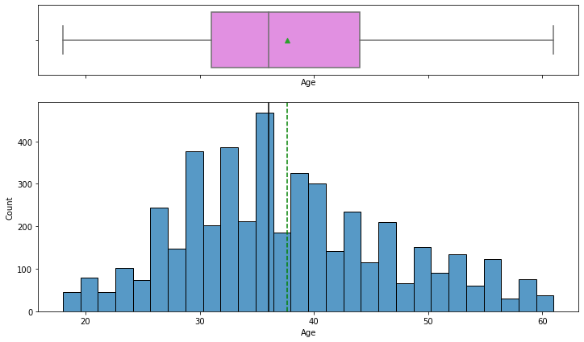

```python
histogram_boxplot(tour, "Age")
```

```python
#fill in missings of numeric variables with median
#fairly normal dataset, mean and median are close together
tour['Age'] = tour['Age'].fillna(tour['Age'].median())
```

```python
#confirm that age no longer has NA
#tour.isnull().sum()
```

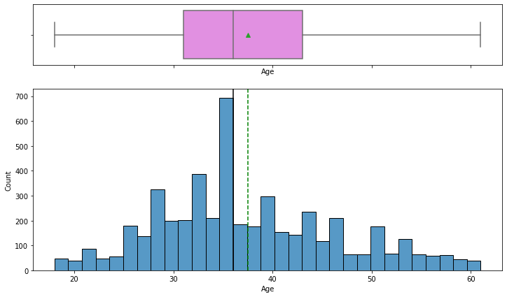

```python
histogram_boxplot(tour, "Age")
```

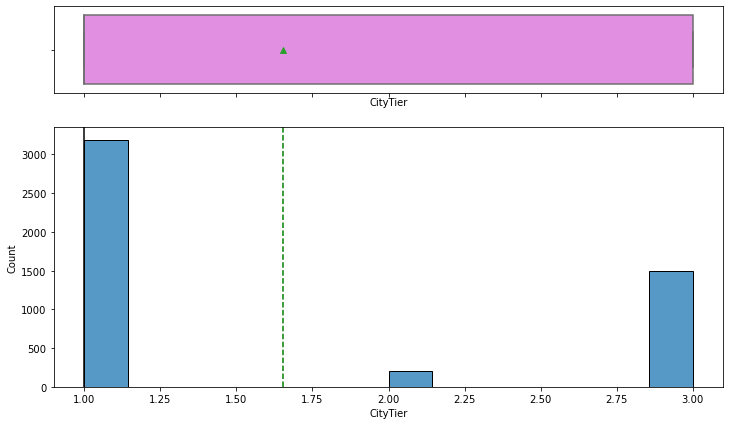

```python
histogram_boxplot(tour, "CityTier")
```

All values for city tier are as expected.

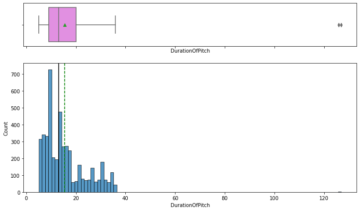

```python
histogram_boxplot(tour, "DurationOfPitch")
#missing values
```

```python
tour['DurationOfPitch'].value_counts()
```

```
9.0      483
7.0      342
8.0      333
6.0      307
16.0     274
15.0     269
14.0     253
10.0     244
13.0     223
11.0     205
12.0     195
17.0     172
30.0      95
22.0      89
31.0      83
23.0      79
18.0      75
32.0      74
29.0      74
21.0      73
25.0      73
27.0      72
26.0      72
24.0      70
35.0      66
20.0      65
28.0      61
33.0      57
19.0      57
34.0      50
36.0      44
5.0        6
126.0      1
127.0      1
Name: DurationOfPitch, dtype: int64
```

Duration of pitch has two very large outliers. I will pull these values back to be one greater than the largest value inthe current dataset.

```python
tour['DurationOfPitch'] = np.where(tour.DurationOfPitch > 36, 37, tour.DurationOfPitch)
```

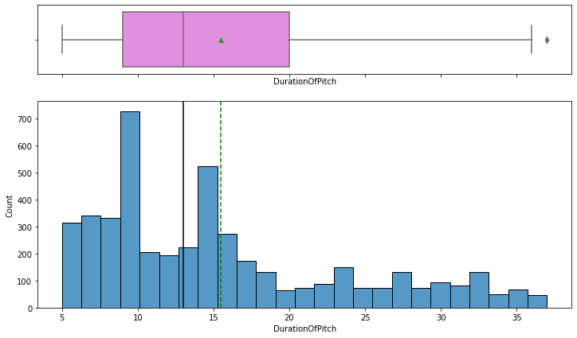

```python
#re-evaluate the distribution after outliers recoded
histogram_boxplot(tour, "DurationOfPitch")
```

```python
#best method of replacing missings is mean
tour['DurationOfPitch'] = tour['DurationOfPitch'].fillna(tour['DurationOfPitch'].mean())
```

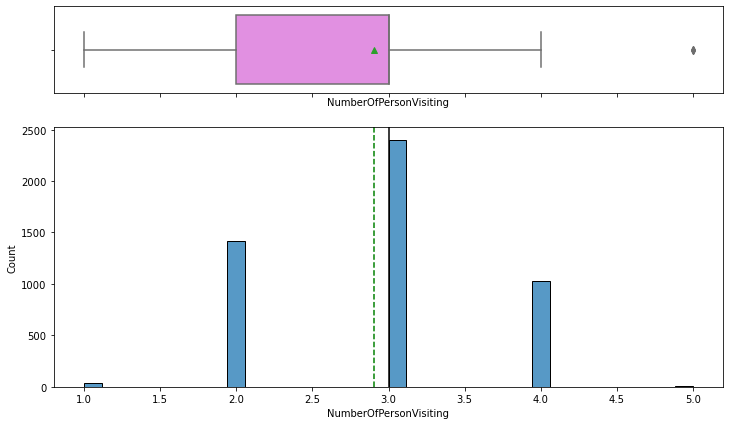

```python
histogram_boxplot(tour, "NumberOfPersonVisiting")
```

```python
tour['NumberOfPersonVisiting'].value_counts()
```

```
3    2402
2    1418
4    1026
1      39
5       3
Name: NumberOfPersonVisiting, dtype: int64
```

Given the low count of observations with a value of 5, group these in with the 4s.

```python
tour['NumberOfPersonVisiting'] = np.where(tour.NumberOfPersonVisiting > 4, 4, tour.NumberOfPersonVisiting)
```

```python
#validate changes
tour['NumberOfPersonVisiting'].value_counts()
```

```
3    2402
2    1418
4    1029
1      39
Name: NumberOfPersonVisiting, dtype: int64
```

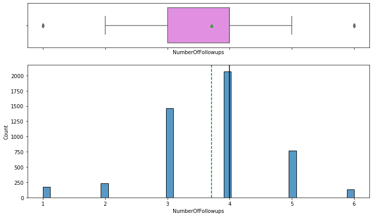

```python
histogram_boxplot(tour, "NumberOfFollowups")
#missing values
```

```python
tour['NumberOfFollowups'].value_counts()
```

```
4.0    2068
3.0    1466
5.0     768
2.0     229
1.0     176
6.0     136
Name: NumberOfFollowups, dtype: int64
```

The number of observations for each value of number of followups will be informative and not lead to instability in the model

```python
#if number of followups is missing fill in value of 4
tour['NumberOfFollowups'] = tour['NumberOfFollowups'].fillna(tour['NumberOfFollowups'].mode()[0])
```

```python
#validate change
tour['NumberOfFollowups'].value_counts()
```

```
4.0    2113
3.0    1466
5.0     768
2.0     229
1.0     176
6.0     136
Name: NumberOfFollowups, dtype: int64
```

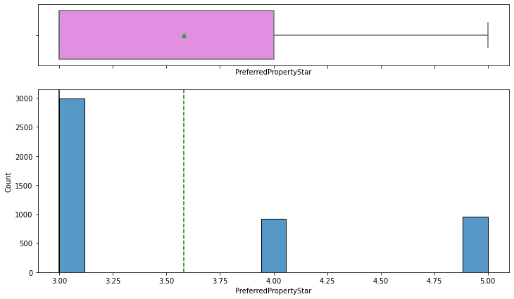

```python
histogram_boxplot(tour, "PreferredPropertyStar")
#missing values
```

```python
tour['PreferredPropertyStar'].value_counts()
```

```
3.0    2993
5.0     956
4.0     913
Name: PreferredPropertyStar, dtype: int64
```

Values for preferred property star are all reasonable. Use the mode for filling in missing values.

```python
#if number of followups is missing fill in value of 3
tour['PreferredPropertyStar'] = tour['PreferredPropertyStar'].fillna(tour['PreferredPropertyStar'].mode()[0])
```

```python
#verify change
tour['PreferredPropertyStar'].value_counts()
```

```
3.0    3019
5.0     956
4.0     913
Name: PreferredPropertyStar, dtype: int64
```

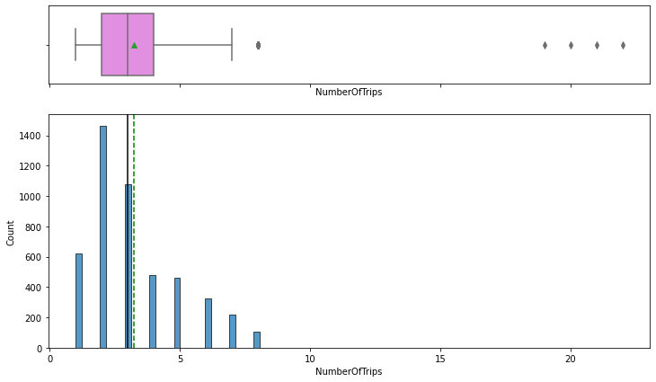

```python
histogram_boxplot(tour, "NumberOfTrips")
#missing values
```

```python
#EVALUATE OUTLIERS
tour['NumberOfTrips'].value_counts()
```

```
2.0     1464
3.0     1079
1.0      620
4.0      478
5.0      458
6.0      322
7.0      218
8.0      105
21.0       1
19.0       1
22.0       1
20.0       1
Name: NumberOfTrips, dtype: int64
```

```python
#if number of trips >8 then set value to 8
tour['NumberOfTrips'] = np.where(tour.NumberOfTrips > 8, 8, tour.NumberOfTrips)
```

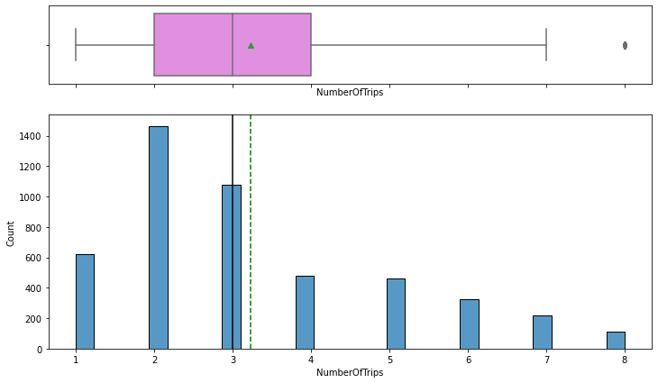

```python
#re-evaluate distribution to determine how to handle missings
histogram_boxplot(tour, "NumberOfTrips")
```

```python
#missing value treatment
tour["NumberOfTrips"] = tour["NumberOfTrips"].fillna(tour["NumberOfTrips"].mode()[0])
```

```python
#validate change
tour['NumberOfTrips'].value_counts()
```

```
2.0    1604
3.0    1079
1.0     620
4.0     478
5.0     458
6.0     322
7.0     218
8.0     109
Name: NumberOfTrips, dtype: int64
```

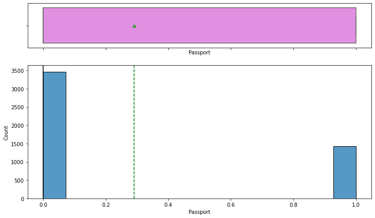

```python
histogram_boxplot(tour, "Passport")
```

Values of passport are all reasonable.

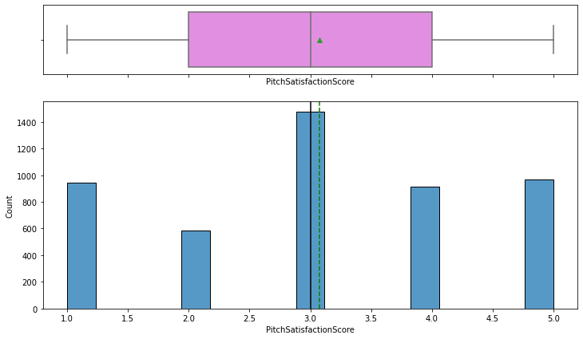

```python
histogram_boxplot(tour, "PitchSatisfactionScore")
```

Values of pitch satisfaction score are all reasonable.

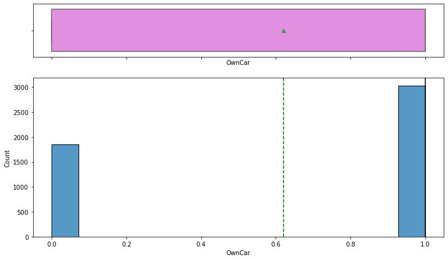

```python
histogram_boxplot(tour, "OwnCar")
```

Values of owncar are all reasonable.

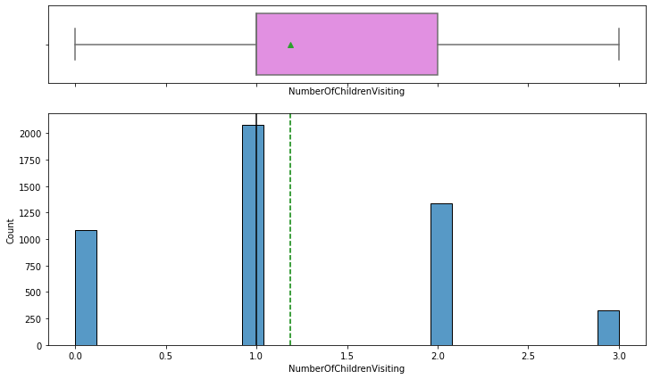

```python
histogram_boxplot(tour, "NumberOfChildrenVisiting")
#missing values
```

```python
tour['NumberOfChildrenVisiting'].value_counts()
```

```
1.0    2080
2.0    1335
0.0    1082
3.0     325
Name: NumberOfChildrenVisiting, dtype: int64
```

Values of number of children missing are all reasonable. Set missings to 1 as the mode and median are similar.

```python
#missing value treatment
tour["NumberOfChildrenVisiting"] = tour["NumberOfChildrenVisiting"].fillna(tour["NumberOfChildrenVisiting"].mode()[0])
```

```python
tour['NumberOfChildrenVisiting'].value_counts()
```

```
1.0    2146
2.0    1335
0.0    1082
3.0     325
Name: NumberOfChildrenVisiting, dtype: int64
```

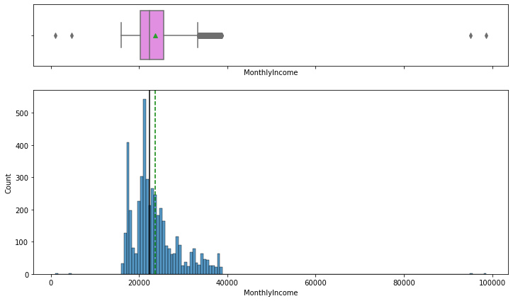

```python
histogram_boxplot(tour, "MonthlyIncome")
#missing values
```

```python
#tour['MonthlyIncome'].value_counts()
#this code doesn't work well for continuous variables
#need to look at values below 1500 and above 4000
```

We will need outlier treatment for both very high and very low values of monthly income.

```python
#Outlier treatment for high values
tour['MonthlyIncome'] = np.where(tour.MonthlyIncome > 40000, 40000, tour.MonthlyIncome)
```

```python
#Outlier treatment for low values
tour['MonthlyIncome'] = np.where(tour.MonthlyIncome < 15000, 15000, tour.MonthlyIncome)
```

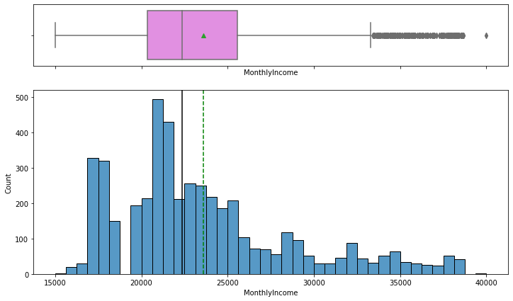

```python
#re-evaluate distribution
histogram_boxplot(tour, "MonthlyIncome")
```

```python
#treatment for missing values
tour["MonthlyIncome"] = tour["MonthlyIncome"].fillna(tour["MonthlyIncome"].median())
```

```python
#confirm that all variables  no longer have NA
tour.isnull().sum()
```

```
CustomerID                       0
ProdTaken                        0
Age                              0
CityTier                         0
DurationOfPitch                  0
NumberOfPersonVisiting           0
NumberOfFollowups                0
PreferredPropertyStar            0
NumberOfTrips                    0
Passport                         0
PitchSatisfactionScore           0
OwnCar                           0
NumberOfChildrenVisiting         0
MonthlyIncome                    0
TypeofContact_Company Invited    0
TypeofContact_Self Enquiry       0
Occupation_Large Business        0
Occupation_Salaried              0
Occupation_Small Business        0
Gender_Female                    0
Gender_Male                      0
ProductPitched_Basic             0
ProductPitched_Deluxe            0
ProductPitched_King              0
ProductPitched_Standard          0
ProductPitched_Super Deluxe      0
MaritalStatus_Divorced           0
MaritalStatus_Married            0
MaritalStatus_Single             0
MaritalStatus_Unmarried          0
Designation_AVP                  0
Designation_Executive            0
Designation_Manager              0
Designation_Senior Manager       0
Designation_VP                   0
dtype: int64
```

Univariate analysis is complete. Outlier and missing value treatment is complete. For some types of analysis, we can refer back to the original dataset, as missing value treatment is part of the algorithm.

# Bivariate analysis

```python
#drop the customer ID variable - not needed for modeling or analysis
tour=tour.drop(columns="CustomerID")
```

First, let's examine the correlations between variables for any patterns that pop out right away.

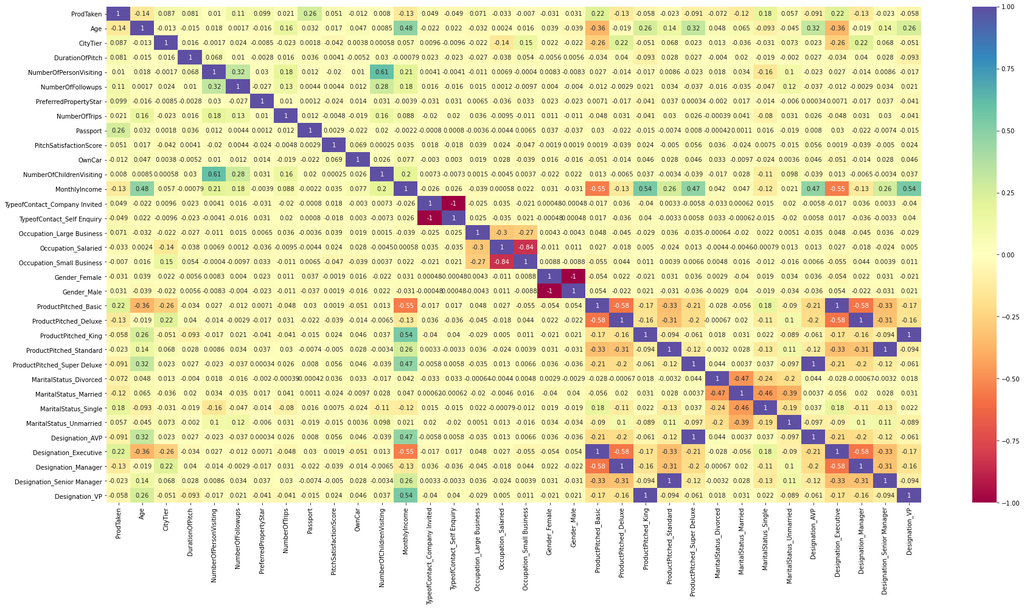

```python
plt.figure(figsize=(30,15))
sns.heatmap(tour.corr(),annot=True,vmin=-1,vmax=1,cmap="Spectral")
plt.show()
```

```python
#sns.pairplot(data=tour,hue="ProdTaken")
#plt.show()
```

Next, let's look at each variable by the target variable "ProdTaken". From the discussion board: "While ProdTaken is not specifically the new "Wellness Tourism" package, it is still a tourism package (either Basic, Standard, Deluxe, Super Deluxe, or King).

We don't have enough information about how the packages compare to the new "Wellness Tourism" package so we can't say whether buying a specific package over another package is a better indicator for buying the "Wellness Tourism" package.

As a result, I think the best variable to use as the dependent variable is ProdTaken despite it being a little more general than our final objective."

# Box plots for continuous variables

```python
### Function to plot boxplot
def boxplot(x):
    plt.figure(figsize=(10,7))
    sns.boxplot(data=tour, x="ProdTaken",y=tour[x],palette="PuBu")
    plt.show()
```

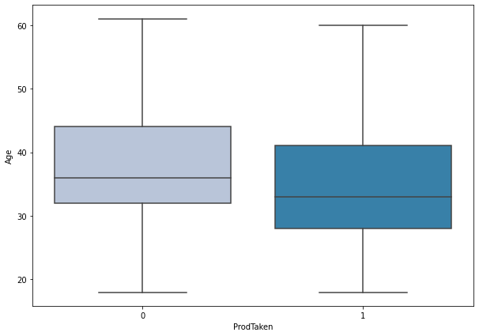

```python
boxplot('Age')
```

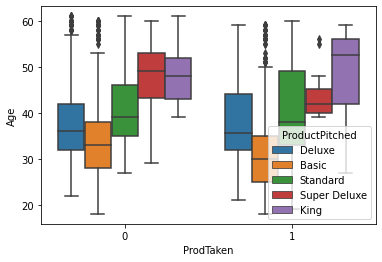

```python
sns.boxplot(x=tour_orig.ProdTaken,y=tour_orig.Age,hue=tour_orig.ProductPitched)
```

customers who purchased a package were slightly younger than those who did not take a package

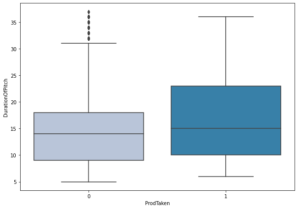

```python
boxplot('DurationOfPitch')
```

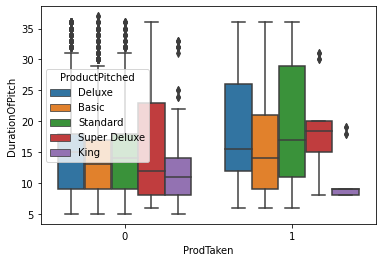

```python
sns.boxplot(x=tour_orig.ProdTaken,y=tour.DurationOfPitch,hue=tour_orig.ProductPitched)
```

Those who purchased a package had a slightly longer pitch time

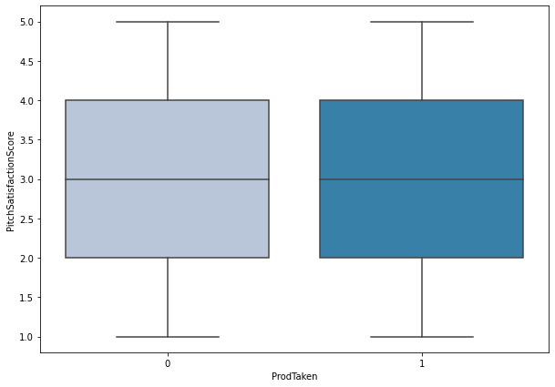

```python
boxplot('PitchSatisfactionScore')
```

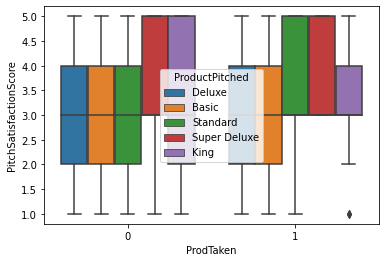

```python
sns.boxplot(x=tour_orig.ProdTaken,y=tour_orig.PitchSatisfactionScore,hue=tour_orig.ProductPitched)
```

There was not a difference in pitch satisfaction score between those who purchased a package ad those who did not

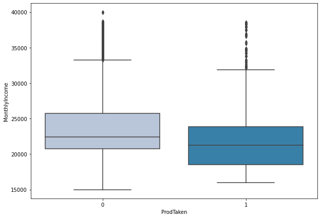

```python
boxplot('MonthlyIncome')
```

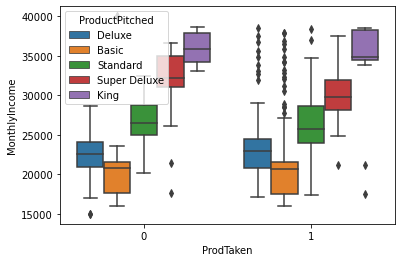

```python
sns.boxplot(x=tour_orig.ProdTaken,y=tour.MonthlyIncome,hue=tour_orig.ProductPitched)
```

Those who purchased a package had a slightly lower average monthly income than those who did not purchase a package